# Coursera Assignment

Rajesh More

March 6, 2016

## Reproducible Research: Peer Assessment 1

**1. Loading and preprocessing the data**

Read raw data into input_raw_data varable Load the data (i.e. 𝚛𝚎𝚊𝚍.𝚌𝚜𝚟()) Process/transform the data (if necessary) into a format suitable for your analysis

```r
library(lattice)
setwd("~/Documents/Coursera/Reproducible Research/week1/assignment/Reproducible-Research-Assignment-1")
input_raw_data <- read.csv("activity.csv",header = TRUE,sep = ",")
input_raw_data$date <- as.Date(input_raw_data$date, "%Y-%m-%d")
input_raw_data_new <- input_raw_data
summary(input_raw_data)
```

```
##      steps             date               interval
##  Min.   :  0.00   Min.   :2012-10-01   Min.   :   0.0
##  1st Qu.:  0.00   1st Qu.:2012-10-16   1st Qu.: 588.8
##  Median :  0.00   Median :2012-10-31   Median :1177.5
##  Mean   : 37.38   Mean   :2012-10-31   Mean   :1177.5
##  3rd Qu.: 12.00   3rd Qu.:2012-11-15   3rd Qu.:1766.2
##  Max.   :806.00   Max.   :2012-11-30   Max.   :2355.0
##  NA's   :2304
```

**2. What is mean total number of steps taken per day?**

Calculate the total number of steps taken per day. Get total steps per day - using tapply (group by date and find sum for steps )

Check bar plot - barplot(totstepsbydate) Plot histogram

```
totstepsbydate <- tapply(input_raw_data$steps, input_raw_data$date, sum)
hist(totstepsbydate,  xlab = "Steps Per Day", ylab = "Interval", main = "Steps per day")
```

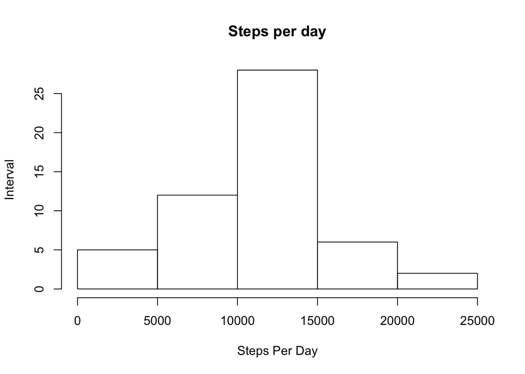

**Remove missing values (remove .NA)**

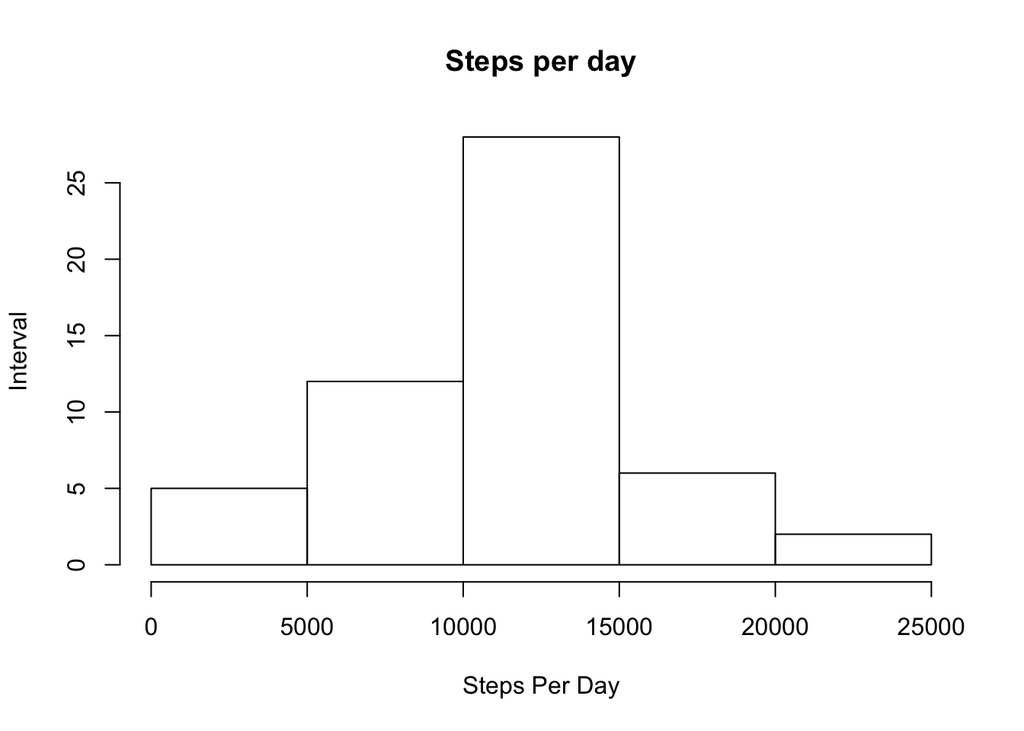

Find mean and median

```r
meanvalue <- mean(totstepsbydate)
meanvalue
```

```
## [1] 10766.19
```

```r
medianvalue <- median(totstepsbydate)
medianvalue
```

```
## [1] 10765
```

**3. What is the average daily activity pattern?**

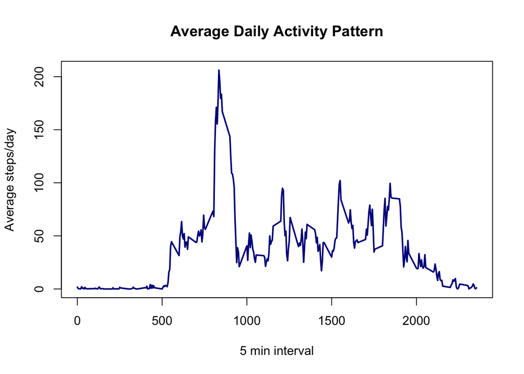

```r
# To find average get mean
meansteps <- tapply(input_raw_data$steps, input_raw_data$interval, mean,na.rm = TRUE)
# Plot line graph for Average daily activity pattern
plot(row.names(meansteps), meansteps, type = "l", xlab = "5 min interval",
 ylab = "Average steps/day", main = "Average Daily Activity Pattern", col = "dark blue", lwd = 2 )
```

**4. Imputing missing values**

Calculate and report the total number of missing values in the dataset (i.e. the total number of rows with 𝙽𝙰. s)Use complete.cases - it return a logical vector indicating which cases are complete, i.e., have no missing values. Get NA set with !

```r
nrow(input_raw_data_new[!complete.cases(input_raw_data_new),])
```

```
## [1] 2304
```

```r
for (i in 1:dim(input_raw_data_new)[1]) {
   ifelse (is.na(input_raw_data_new$steps[i]) ,   input_raw_data_new$steps[i] <- mean(meansteps) ,NA)
  }
```

Check record count with and without NA

```r
# rows with NA values
nrow(input_raw_data[!complete.cases(input_raw_data),])
```

```
## [1] 2304
```

```r
# rows with NA values (NA removed)
nrow(input_raw_data_new[!complete.cases(input_raw_data_new),])
```

```
## [1] 0
```

Histogram after removing NA

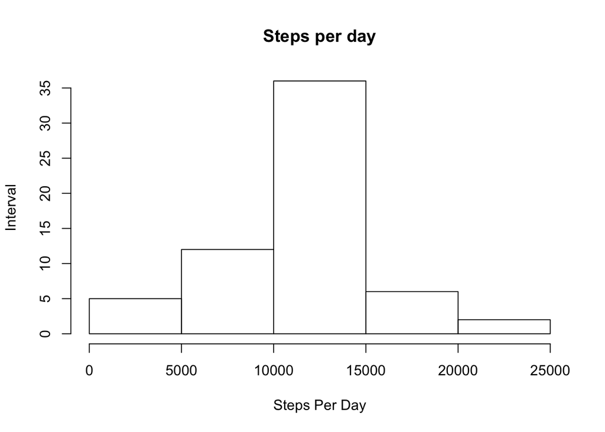

```r
totstepsbydate_new <- tapply(input_raw_data_new$steps, input_raw_data_new$date, sum)
hist(totstepsbydate_new,  xlab = "Steps Per Day", ylab = "Interval", main = "Steps per day")
```

Find mean and median value with and without NA

```r
meanvalue_new <- mean(totstepsbydate_new)
# Mean with NA
meanvalue
```

```
## [1] 10766.19
```

```r
# Mean without NA
meanvalue_new
```

```
## [1] 10766.19
```

```r
medianvalue_new <- median(totstepsbydate_new)
# Median with NA
medianvalue
```

```
## [1] 10765
```

```r
# Median with NA
medianvalue_new
```

```
## [1] 10766.19
```

**5. Are there differences in activity patterns between weekdays and weekends?**

```r
day <- weekdays(input_raw_data_new$date)
week_weekend <- vector()
for (i in 1:nrow(input_raw_data_new)) {
  if (day[i] == "Saturday") {
    week_weekend[i] <- "Weekend"
  } else if (day[i] == "Sunday") {
    week_weekend[i] <- "Weekend"
  } else {
    week_weekend[i] <- "Weekday"
  }
}
```

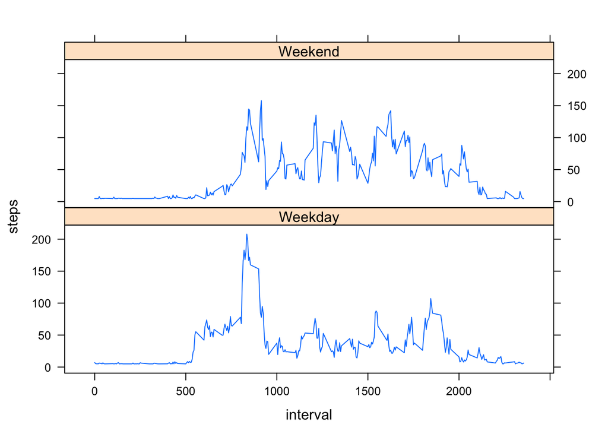

```r
# Add daylevel to input_raw_data_new
input_raw_data_new$week_weekend <- week_weekend
input_raw_data_new$week_weekend <- factor(input_raw_data_new$week_weekend)

# split data and find mean steps for interval/day
stepsperday <- aggregate(steps ~ interval + week_weekend, data = input_raw_data_new, mean)
names(stepsperday) <- c("interval", "week_weekend", "steps")
# Plot week vs weekend chart
xyplot(steps ~ interval | week_weekend, stepsperday, type = "l", layout = c(1, 2),xlab = "interval", ylab = "steps")
```